# Lab 6 Key

Daniel Anderson

10/28/2018

# Data prep

Copy and paste your code from class to load the *glo_sim.sav* data into the chunk below.

```r
library(tidyverse)
library(here)
library(rio)
theme_set(theme_minimal())

d <- import(here("data", "glo_sim.sav"),
            setclass = "tbl_df") %>%
  characterize()
```

Knit the file immediately. If you get an error from the chunk below, keep working until your data are loaded correctly (and get help if you need it).

```r
head(d)
```

```
## # A tibble: 6 x 14
##   condition         age  aces   sex_risk internalizing externalizing
##   <chr>           <dbl> <dbl>      <dbl>         <dbl>         <dbl>
## 1 Control      15.85763     3 -0.6215645            16            12
## 2 Intervention 15.48255     0  0.4536259             9            13
## 3 Control      13.49213     0 -0.6434958             3             0
## 4 Intervention 14.21766     1 -0.6514939            11            16
## 5 Intervention 17.29500     4  1.151312              9             1
## 6 Intervention 14.80630     3 -0.6855188             9             5
## # ... with 8 more variables: parent_education <chr>, parent_income <chr>,
## #   parent <chr>, teen_eth <chr>, teen_race <chr>, parent_eth <chr>,
## #   parent_race <chr>, id <chr>
```

# Scenario

A randomized control trial is being conducted on an intervention designed to reduce girls engagement in risky sexual behavior. The variable `condition` within the dataset states whether the participant was in the control or intervention condition.

Fit a model evaluating the effect of the intervention, controlling for the age of the participant and their adverse childhood experiences score (aces), on their sexual risk score.

```r
d %>%
  mutate(condition = factor(condition),
         condition = relevel(condition, ref = "Control"))
```

```
## # A tibble: 119 x 14
##    condition         age  aces   sex_risk internalizing externalizing
##    <fct>           <dbl> <dbl>      <dbl>         <dbl>         <dbl>
##  1 Control      15.85763     3 -0.6215645            16            12
##  2 Intervention 15.48255     0  0.4536259             9            13
##  3 Control      13.49213     0 -0.6434958             3             0
##  4 Intervention 14.21766     1 -0.6514939            11            16
##  5 Intervention 17.29500     4  1.151312              9             1
##  6 Intervention 14.80630     3 -0.6855188             9             5
##  7 Intervention 14.60917     3  0.1376239             9             6
##  8 Intervention 18.08624     0  0.2725986             6             7
##  9 Intervention 14.51061     4  0.1848870            19            18
## 10 Intervention 15.32375     5  0.4286057            19            19
## # ... with 109 more rows, and 8 more variables: parent_education <chr>,
## #   parent_income <chr>, parent <chr>, teen_eth <chr>, teen_race <chr>,
## #   parent_eth <chr>, parent_race <chr>, id <chr>
```

```r
m1 <- lm(sex_risk ~ condition + aces, d)
summary(m1)
```

```
##
## Call:
## lm(formula = sex_risk ~ condition + aces, data = d)
##
## Residuals:
##     Min      1Q  Median      3Q     Max
## -1.2231 -0.5012 -0.1005  0.4117  1.9732
##
## Coefficients:
##                       Estimate Std. Error t value Pr(>|t|)
## (Intercept)           -0.39915    0.10814  -3.691 0.000342 ***
## conditionIntervention  0.26005    0.12144   2.141 0.034331 *
## aces                   0.10612    0.02853   3.720 0.000309 ***
## ---
## Signif. codes:  0 '***' 0.001 '**' 0.01 '*' 0.05 '.' 0.1 ' ' 1
##
## Residual standard error: 0.6557 on 116 degrees of freedom
## Multiple R-squared:  0.1536, Adjusted R-squared:  0.139
## F-statistic: 10.52 on 2 and 116 DF,  p-value: 6.319e-05
```

Calculate the squared semipartial correlations

```r
library(lmSupport)
modelEffectSizes(m1)
```

```
## lm(formula = sex_risk ~ condition + aces, data = d)
##
## Coefficients
##                SSR df pEta-sqr dR-sqr
## (Intercept) 5.8583  1   0.1051     NA
## condition   1.9717  1   0.0380 0.0335
## aces        5.9484  1   0.1066 0.1010
##
## Sum of squared errors (SSE): 49.9
## Sum of squared total  (SST): 58.9
```

In the space below, briefly explain the results of the investigation. Interpret the coefficient for the intervention. Reference the unique variance accounted for by the intervention, as well as the uncertainty of the estimate.

The model suggests that, when controlling for ACEs, girls in the intervention condition had a significantly higher sexual risk scores ($b = 0.26, SE = 0.12, t = 2.14, p = 0.03$) than girls in the control condition. Overall, the model accounted for approximately 15% of the total variability in sexual risk scores, while the intervention uniquely accounted for 3.4% of the total variability.

Modify the code below to produce a coefficient plot

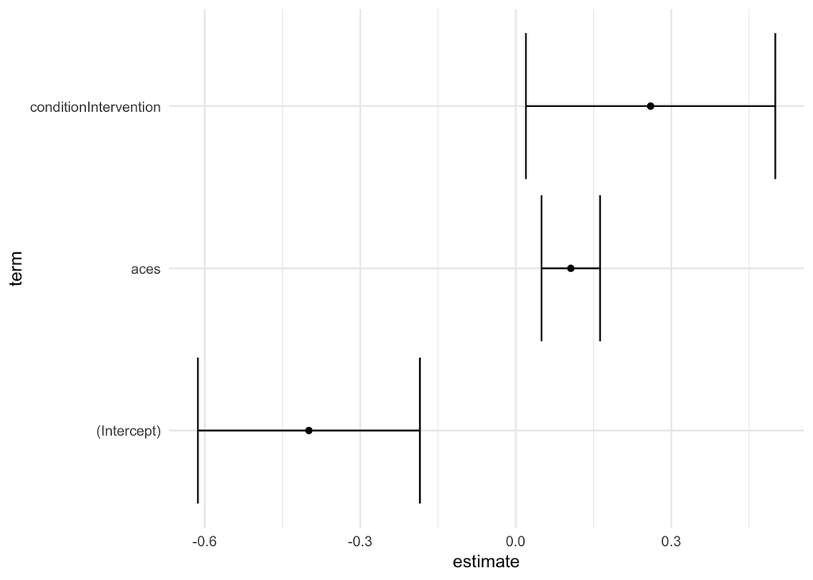

```r
library(broom)
tidy_pd <- tidy(m1, conf.int = TRUE)

ggplot(tidy_pd, aes(term, estimate)) +
  geom_point() +
  geom_errorbar(aes(ymin = conf.low, ymax = conf.high)) +
  coord_flip()
```

In the chunk below, fit the same model as above, but with the intervention variable removed.

```r
reduced_m1 <- lm(sex_risk ~  aces, d)
```

In the chunk below provde a summary of the full model and the reduced model. Calculate the difference in the Model $R^2$ from the two models.

```r
summary(m1)
```

```
##
## Call:
## lm(formula = sex_risk ~ condition + aces, data = d)
##
## Residuals:
##     Min      1Q  Median      3Q     Max
## -1.2231 -0.5012 -0.1005  0.4117  1.9732
##
## Coefficients:
##                       Estimate Std. Error t value Pr(>|t|)
## (Intercept)           -0.39915    0.10814  -3.691 0.000342 ***
## conditionIntervention  0.26005    0.12144   2.141 0.034331 *
## aces                   0.10612    0.02853   3.720 0.000309 ***
## ---
## Signif. codes:  0 '***' 0.001 '**' 0.01 '*' 0.05 '.' 0.1 ' ' 1
##
## Residual standard error: 0.6557 on 116 degrees of freedom
## Multiple R-squared:  0.1536, Adjusted R-squared:  0.139
## F-statistic: 10.52 on 2 and 116 DF,  p-value: 6.319e-05
```

```r
summary(reduced_m1)
```

```
##
## Call:
## lm(formula = sex_risk ~ aces, data = d)
##
## Residuals:
##     Min      1Q  Median      3Q     Max
## -1.4024 -0.4911 -0.1448  0.4746  2.0742
##
## Coefficients:
##             Estimate Std. Error t value Pr(>|t|)
## (Intercept) -0.28792    0.09629  -2.990 0.003399 **
## aces         0.11462    0.02868   3.996 0.000113 ***
## ---
## Signif. codes:  0 '***' 0.001 '**' 0.01 '*' 0.05 '.' 0.1 ' ' 1
##
## Residual standard error: 0.6657 on 117 degrees of freedom
## Multiple R-squared:  0.1201, Adjusted R-squared:  0.1126
## F-statistic: 15.97 on 1 and 117 DF,  p-value: 0.000113
```

```r
0.1536 - 0.1201
```

```
## [1] 0.0335
```

In the space below, describe how your calculation corresponded to the squared semi-partial correlation you calculated previously. Explain why the values are or are not similar.

The difference in the $R^2$ values is exactly the same because the squared semi-partial correlation represents the unique variance accounted for by the model, which can also be estimated by looking at the differences in the model $R^2$ between two models with only one variable differing.

Produce a plot to inspect outliers in the code chunk below. I’ve provided some sample code can use, or you can use alternative methods if you’d prefer.

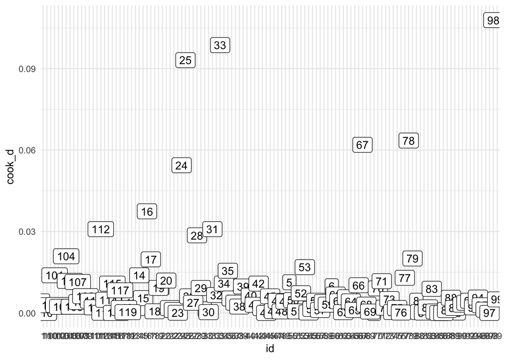

```r
d <- d %>%
    mutate(cook_d = cooks.distance(m1))

ggplot(d, aes(id, cook_d)) +
        geom_label(aes(label = id))
```

Produce a plot of the fitted values against the model residuals in the chunk below

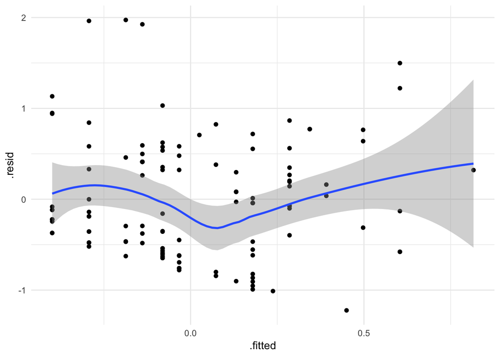

```r
ggplot(m1, aes(.fitted, .resid)) +
  geom_point() +
  geom_smooth()
```

Do you notice anything in these plots that appears concerning?

No. Even the largest Cook’s D is very small and likely not unduly influential. Although there is possibly a slight relation with the fitted/residual plot, and there is some evidence of heteroskedasticy, the violations are unlikely to have much effect on the overall model results.